# DM Statistique Bayésienne

ZhuQing ZHONG

30/05/2022

### Importer le jeu de données

```r
d_muta=read.csv("mutations2.csv")
```

```r
summary(d_muta)
```

[output not shown]

```r
head(d_muta)
```

[output not shown]

### Matrice de corrélation

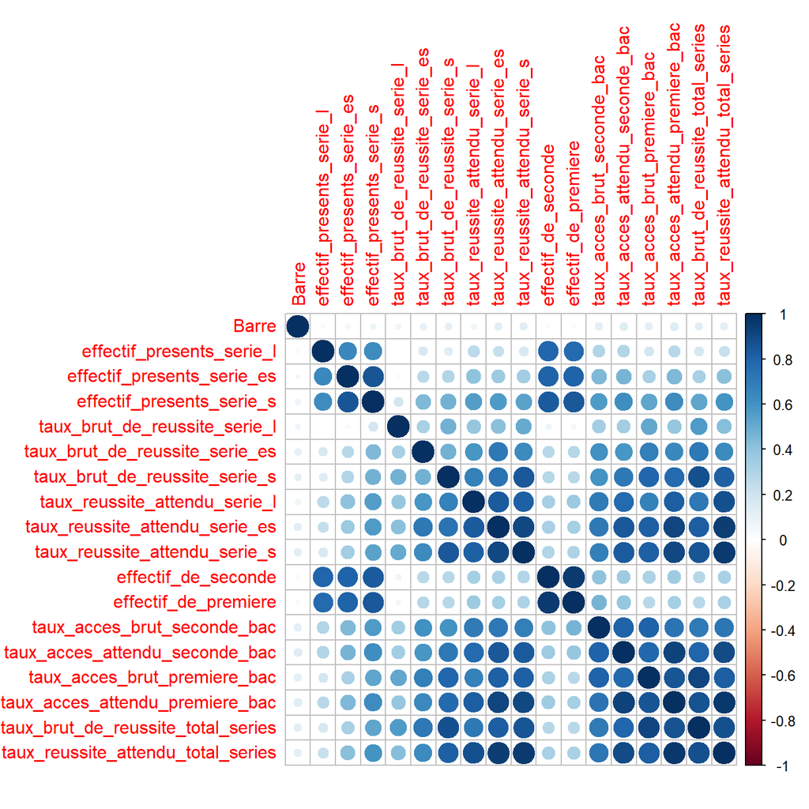

```r
library('corrplot')
d_cor=cor(d_muta[,6:23])
corrplot(d_cor)
```

Comme indiqué par la matrice de corrélation, plusieurs covariables sont fortement corrélées entre eux. Pour cela, il est important de faire une sélection des covariables à inclure dans les modèles.

### Paramétres globals

```r
attach(d_muta)
options(scipen=5)
```

# Régression linéaire

## Question 1

### Regression Linéaire Fréquentiste

Tout d’abord, j’ajuste une régression linéaire classique en incluant tous les covariables quantitatives.

```r
lm1=lm(Barre~.,d_muta[,6:23])
summary(lm1)
```

```
##
## Call:
## lm(formula = Barre ~ ., data = d_muta[, 6:23])
##
## Residuals:
##     Min      1Q  Median      3Q     Max
## -429.72 -205.90 -122.25   -8.55 1645.96
##
## Coefficients:
##                                       Estimate  Std. Error t value Pr(>|t|)
## (Intercept)                        -472.528114  558.630331  -0.846   0.3980
## effectif_presents_serie_l             0.778055    1.638310   0.475   0.6351
## effectif_presents_serie_es            0.292441    1.234437   0.237   0.8128
## effectif_presents_serie_s             0.009694    1.019110   0.010   0.9924
## taux_brut_de_reussite_serie_l         3.121824    2.559498   1.220   0.2232
## taux_brut_de_reussite_serie_es        4.811087    4.205052   1.144   0.2531
## taux_brut_de_reussite_serie_s         9.384937    6.382557   1.470   0.1421
## taux_reussite_attendu_serie_l       -14.284826    6.878696  -2.077   0.0383 *
## taux_reussite_attendu_serie_es        3.814350    8.261299   0.462   0.6445
## taux_reussite_attendu_serie_s        -4.299223    9.586168  -0.448   0.6540
## effectif_de_seconde                   0.043061    0.622939   0.069   0.9449
## effectif_de_premiere                 -0.352071    0.718243  -0.490   0.6242
## taux_acces_brut_seconde_bac          10.744439    5.654922   1.900   0.0580 .
## taux_acces_attendu_seconde_bac       -7.077486    9.038149  -0.783   0.4340
## taux_acces_brut_premiere_bac        -20.386741   10.705943  -1.904   0.0575 .
## taux_acces_attendu_premiere_bac      34.443425   19.164285   1.797   0.0729 .
## taux_brut_de_reussite_total_series   -5.392357   12.884157  -0.419   0.6757
## taux_reussite_attendu_total_series   -4.071861   22.023558  -0.185   0.8534
## ---
## Signif. codes:  0 '***' 0.001 '**' 0.01 '*' 0.05 '.' 0.1 ' ' 1
##
## Residual standard error: 422.4 on 498 degrees of freedom
## Multiple R-squared:  0.04068,    Adjusted R-squared:  0.007931
## F-statistic: 1.242 on 17 and 498 DF,  p-value: 0.2267
```

La qualité de ce modèle est mauvaise avec la valeur de R-squared très petite: 0.0079.

Ensuite, j’ajuste une regression linéaire bayésienne en incluant tous les covariables quantitatives.

```r
library(MCMCpack)
lm_baye1 = MCMCregress(Barre~.,d_muta[,6:23])
summary(lm_baye1)
```

```
##
## Iterations = 1001:11000
## Thinning interval = 1
## Number of chains = 1
## Sample size per chain = 10000
##
## 1. Empirical mean and standard deviation for each variable,
##    plus standard error of the mean:
##
##                                             Mean         SD   Naive SE
## (Intercept)                          -471.194502   562.2856   5.622856
## effectif_presents_serie_l               0.747947     1.6386   0.016386
## effectif_presents_serie_es              0.293011     1.2217   0.012217
## effectif_presents_serie_s               0.002685     1.0201   0.010201
## taux_brut_de_reussite_serie_l           3.067377     2.5464   0.025464
## taux_brut_de_reussite_serie_es          4.718697     4.2082   0.042082
## taux_brut_de_reussite_serie_s           9.280981     6.3220   0.063220
## taux_reussite_attendu_serie_l         -14.233600     6.9518   0.069518
## taux_reussite_attendu_serie_es          3.927556     8.2645   0.082645
## taux_reussite_attendu_serie_s          -4.201077     9.5971   0.095971
## effectif_de_seconde                     0.055184     0.6239   0.006239
## effectif_de_premiere                   -0.356382     0.7169   0.007169
## taux_acces_brut_seconde_bac            10.714782     5.6954   0.056954
## taux_acces_attendu_seconde_bac         -6.939517     9.0293   0.090293
## taux_acces_brut_premiere_bac          -20.395477    10.6488   0.106488
## taux_acces_attendu_premiere_bac        34.597623    19.1565   0.191565
## taux_brut_de_reussite_total_series     -5.160148    12.8893   0.128893
## taux_reussite_attendu_total_series     -4.571465    22.1737   0.221737
## sigma2                             179195.930585 11469.5740 114.695740
##                                    Time-series SE
## (Intercept)                              5.571469
## effectif_presents_serie_l                0.016386
## effectif_presents_serie_es               0.012217
## effectif_presents_serie_s                0.010201
## taux_brut_de_reussite_serie_l            0.025464
## taux_brut_de_reussite_serie_es           0.042082
## taux_brut_de_reussite_serie_s            0.060701
## taux_reussite_attendu_serie_l            0.069518
## taux_reussite_attendu_serie_es           0.082645
## taux_reussite_attendu_serie_s            0.095971
```

[output cut: 37 more lines]

```
## taux_brut_de_reussite_serie_l           4.7799      8.0895
## taux_brut_de_reussite_serie_es          7.5847     13.0012
## taux_brut_de_reussite_serie_s          13.4967     21.7453
## taux_reussite_attendu_serie_l          -9.5655     -0.7551
## taux_reussite_attendu_serie_es          9.4411     20.3334
## taux_reussite_attendu_serie_s           2.2291     14.6360
## effectif_de_seconde                     0.4756      1.2656
## effectif_de_premiere                    0.1309      1.0265
## taux_acces_brut_seconde_bac            14.5368     21.7186
## taux_acces_attendu_seconde_bac         -0.8326     10.7459
## taux_acces_brut_premiere_bac          -13.1695      0.2314
## taux_acces_attendu_premiere_bac        47.4316     72.0897
## taux_brut_de_reussite_total_series      3.4743     19.8602
## taux_reussite_attendu_total_series     10.4683     38.3930
## sigma2                             186508.6337 203153.5749
```

L’espérance des coefficients pour chaque covariable, qui est donné par MCMC, sont proches aux coefficients estimés par la regression fréquentiste. ‘taux_reussite_attendu_serie_l’ est la seule dont l’invervale de crédibilité à 95% ne contient pas 0. Ce modèle bayésien est en accord avec celui de fréquentist ajusté précédemment.

### vérifier la convergence de MCMC

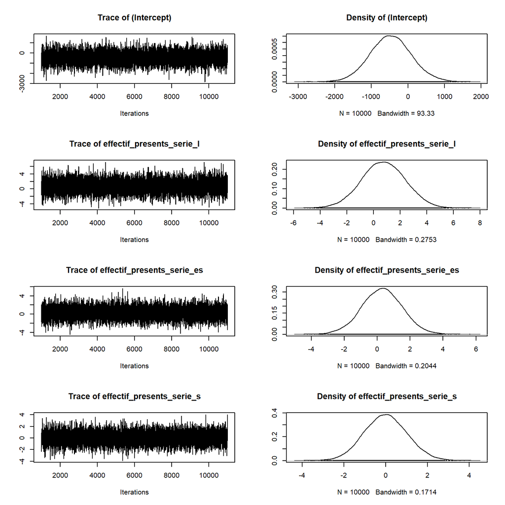

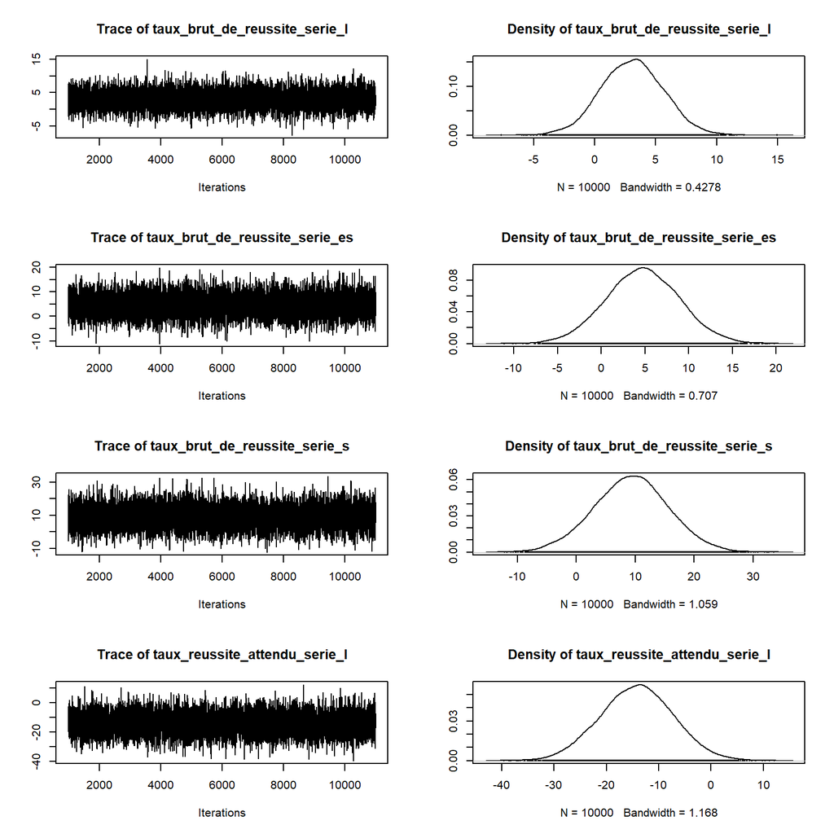

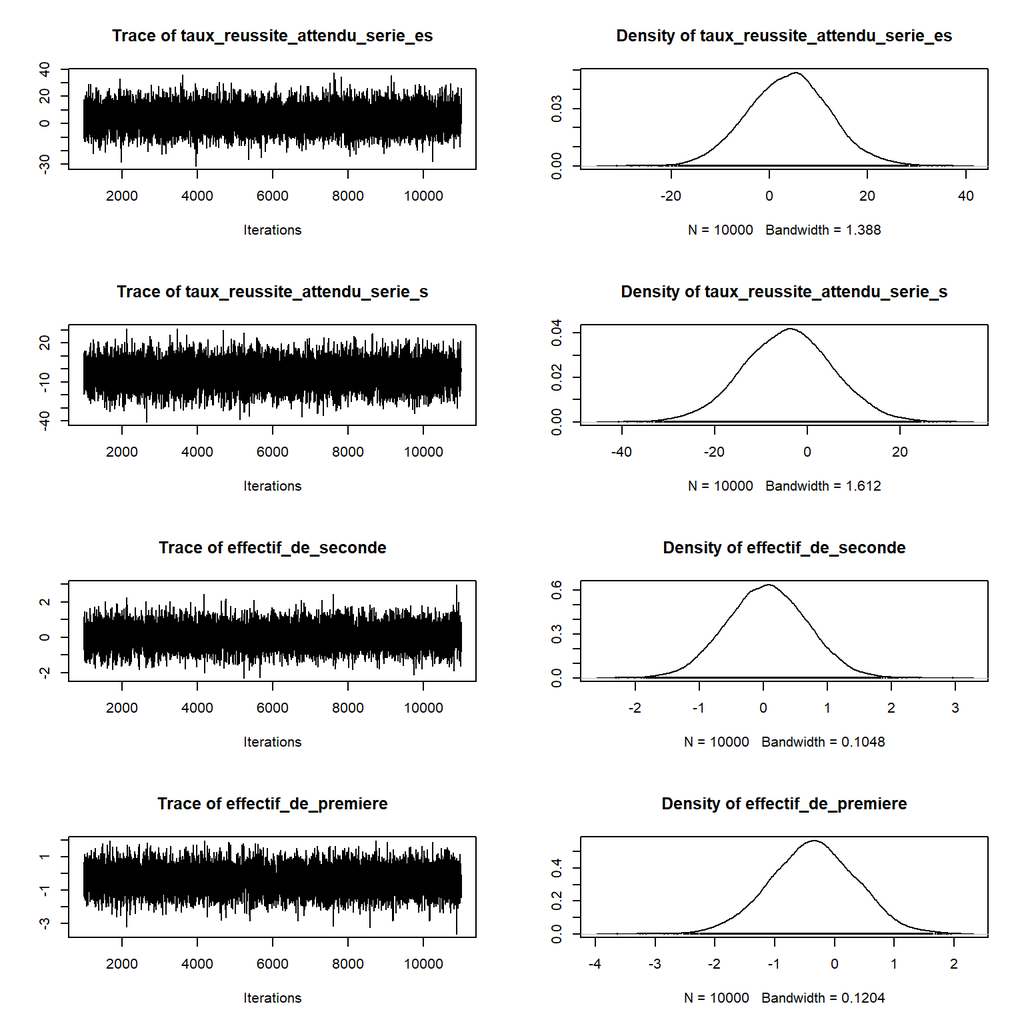

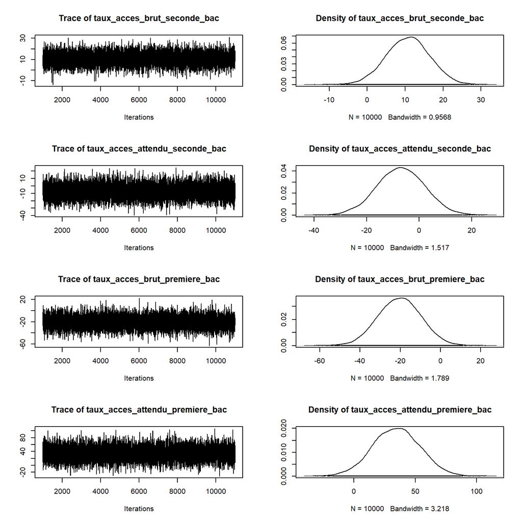

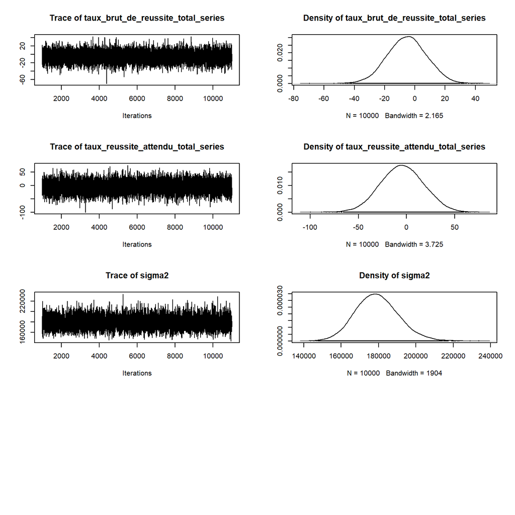

```r
plot(lm_baye1)
```

Les graphes à gauche tracent 1001ième à 11000ième itérations de la Chaîne de Markov. Ces processus apparaissent stationaire et sans mémoire, et ont l’air bien explorer la loi postériori de chaque covariable et de sigma.

```r
raftery.diag(lm_baye1)
```

```
##
## Quantile (q) = 0.025
## Accuracy (r) = +/- 0.005
## Probability (s) = 0.95
##
##                                     Burn-in  Total Lower bound  Dependence
##                                     (M)      (N)   (Nmin)       factor (I)
##  (Intercept)                        2        3897  3746         1.040
##  effectif_presents_serie_l          2        3620  3746         0.966
##  effectif_presents_serie_es         2        3802  3746         1.010
##  effectif_presents_serie_s          2        3710  3746         0.990
##  taux_brut_de_reussite_serie_l      2        3834  3746         1.020
##  taux_brut_de_reussite_serie_es     2        3771  3746         1.010
##  taux_brut_de_reussite_serie_s      2        3834  3746         1.020
##  taux_reussite_attendu_serie_l      2        3680  3746         0.982
##  taux_reussite_attendu_serie_es     2        3620  3746         0.966
##  taux_reussite_attendu_serie_s      2        3771  3746         1.010
##  effectif_de_seconde                2        3710  3746         0.990
##  effectif_de_premiere               2        3834  3746         1.020
##  taux_acces_brut_seconde_bac        2        3710  3746         0.990
##  taux_acces_attendu_seconde_bac     2        3590  3746         0.958
##  taux_acces_brut_premiere_bac       2        3710  3746         0.990
##  taux_acces_attendu_premiere_bac    2        3834  3746         1.020
##  taux_brut_de_reussite_total_series 2        3834  3746         1.020
##  taux_reussite_attendu_total_series 2        3929  3746         1.050
##  sigma2                             2        3680  3746         0.982
```

La diagnostic raftery indique qu’il faut 3746 itérations en minimun pour estimer les coefficients avec un taux de précision à 0.5%. Et la chaine a besoin d’attendre 2 intérations pour atteindre sa loi stationaire. Dans cette regression linéaire bayésienne, 11000 itérations ont été effectué en enlevant les premières 1000 itérations, ce qui est donc suffisant pour l’estimation à ce niveau de précision.

```r
effectiveSize(lm_baye1)
```

```
##                        (Intercept)          effectif_presents_serie_l
##                          10185.315                          10000.000
##         effectif_presents_serie_es          effectif_presents_serie_s
##                          10000.000                          10000.000
##      taux_brut_de_reussite_serie_l     taux_brut_de_reussite_serie_es
##                          10000.000                          10000.000
##      taux_brut_de_reussite_serie_s      taux_reussite_attendu_serie_l
##                          10847.033                          10000.000
##     taux_reussite_attendu_serie_es      taux_reussite_attendu_serie_s
##                          10000.000                          10000.000
##                effectif_de_seconde               effectif_de_premiere
##                          10000.000                          10000.000
##        taux_acces_brut_seconde_bac     taux_acces_attendu_seconde_bac
##                          10000.000                          10082.533
##       taux_acces_brut_premiere_bac    taux_acces_attendu_premiere_bac
##                          10000.000                          10308.289
## taux_brut_de_reussite_total_series taux_reussite_attendu_total_series
##                          10453.020                          10000.000
##                             sigma2
##                           8936.514
```

Le ESS est suffisamment grand pour chaque covariable, ce qui implique la chaine Markov converge bien.

## Question 2

Par la suite, je vais sélectionner les covariables significatives et explorer les modèles probables. Afin de réduire le coût computationnel, j’exclure les 5 covaribales ‘effectif’ dans toutes les analyses suivantes. Les raisons de cette exclusion sont:  
- les coefficients des 5 covariables sont proches de 0, avec les p_value grandes >0.6, estimés dans la regression fréquentiste.  
- l’intervalle de crédibilité pour ces 5 covariables se serre aux alentours de 0, estimé dans la regression bayésienne.

### Sélection des covariables significatives - analyse fréquentist

Je commence par chercher les meilleurs modèles, au sens de BIC, d’une manière exhausive, à l’aide de fonction regsubsets().

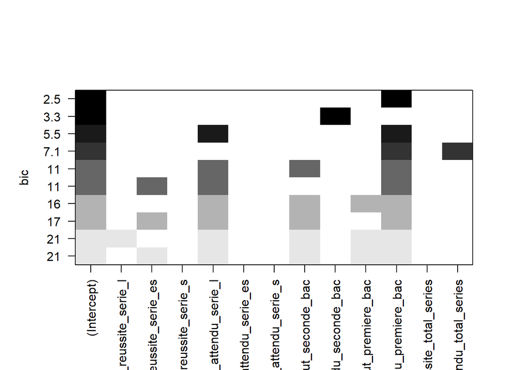

```r
library(leaps)
lm_select=regsubsets(Barre~.,int=T,nbest=2,nvmax=5,method = "exhaustive",data = d_muta[,c(6,10:15,18:23)])
plot(lm_select,scale="bic")
```

Les 3 meilleurs modèles selon la critère d’information BIC sont:  
- 1ier modèle (1 covariable): taux_acces_attendu_premiere_bac  
- 2ième modèle (1 covariable): taux_acces_attendu_seconde_bac  
- 3ième modèle (2 covariables): taux_reussite_attendu_serie_l + taux_acces_attendu_premiere_bac

A rappeler que le meilleurs modèle probablement contient 0 covariable selon le test du Fisher global(p-value =0.2267 ).

### Choix des covariables significatives - analyse bayésienne

```r
library(BMS)
lm_bms=bms(Barre~.,data=d_muta[,c(6,10:15,18:23)],burn=1e3,iter=1e5)
```

```
##                                           PIP   Post Mean   Post SD
## taux_acces_attendu_premiere_bac    0.19264014  1.99670062 4.5643827
## taux_acces_attendu_seconde_bac     0.12418733  0.94939973 2.7381945
## taux_brut_de_reussite_total_series 0.06981247  0.47073850 1.9047015
## taux_reussite_attendu_serie_es     0.06762542  0.39625405 1.6610439
## taux_reussite_attendu_serie_s      0.05800695  0.29348021 1.3592125
## taux_reussite_attendu_total_series 0.05607392  0.29298228 1.9008779
## taux_acces_brut_seconde_bac        0.04366876  0.21103014 1.1226712
## taux_acces_brut_premiere_bac       0.03945916  0.24116657 1.4148932
## taux_brut_de_reussite_serie_s      0.03620620  0.16439173 0.9927095
## taux_brut_de_reussite_serie_es     0.03366672  0.13692470 0.8487615
## taux_reussite_attendu_serie_l      0.02029065 -0.09391459 1.0969112
## taux_brut_de_reussite_serie_l      0.01052302  0.01558611 0.2496186
##                                    Cond.Pos.Sign Idx
## taux_acces_attendu_premiere_bac        1.0000000  10
## taux_acces_attendu_seconde_bac         0.9999551   8
## taux_brut_de_reussite_total_series     0.9992218  11
## taux_reussite_attendu_serie_es         0.9774166   5
## taux_reussite_attendu_serie_s          0.9728651   6
## taux_reussite_attendu_total_series     0.9312897  12
## taux_acces_brut_seconde_bac            0.9999991   7
## taux_acces_brut_premiere_bac           0.9541278   9
## taux_brut_de_reussite_serie_s          0.9997553   3
## taux_brut_de_reussite_serie_es         1.0000000   2
## taux_reussite_attendu_serie_l          0.2049109   4
## taux_brut_de_reussite_serie_l          0.9983806   1
##
## Mean no. regressors               Draws             Burnins                Time
##            "0.7522"              "4096"                 "0"     "0.361053 secs"
##  No. models visited      Modelspace 2^K           % visited         % Topmodels
##              "4096"              "4096"               "100"                "12"
##            Corr PMP            No. Obs.         Model Prior             g-Prior
##                "NA"               "516"        "random / 6"               "UIP"
##     Shrinkage-Stats
##         "Av=0.9981"
##
## Time difference of 0.361053 secs
```

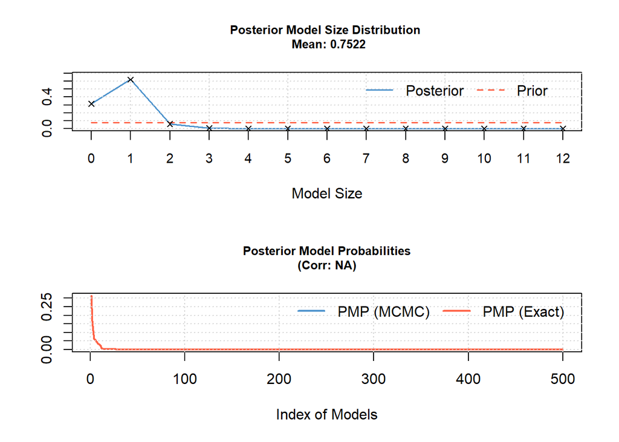

Selon la loi postériori obtenues dans la sortie de bms(), les modèles les plus probables contiennent 0 à 1 covariables.  
Les covariables les plus probablement significatives sont:  
- 1ier: taux_acces_attendu_premiere_bac. 19% de la masse à posteriori a besoin de l’inclure.  
- 2ième: taux_acces_attendu_seconde_bac. 12% de la masse à posteriori a besoin de l’inclure.

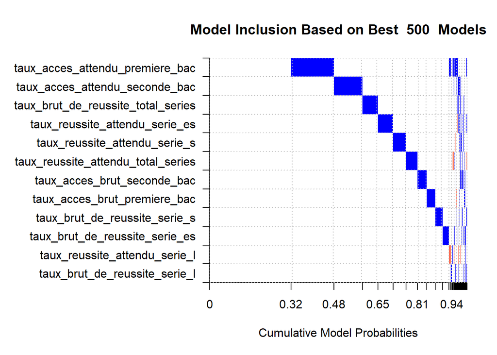

```r
image(lm_bms)
```

Les 3 meilleurs modèles selon l’approche bayésienne sont:  
- 1ier modèle (0 covariable): avec une probabilité de 32%  
- 2ième modèle (1 covariable): taux_acces_attendu_premiere_bac, avec une probabilité de 16%  
- 3ième modèle (1 covariable): taux_acces_attendu_seconde_bac

Pour résumer, l’approche bayésienne est quasiment en accord avec celle fréquentiste au niveau de à la sélection des covariables significative et des meilleurs modèles.

## Question 3

```r
d_math=d_muta[Matiere=="MATHS",]
dim(d_math)
```

```
## [1] 59 23
```

```r
#summary(d_math)
```

```r
d_eng=d_muta[Matiere=="ANGLAIS",]
dim(d_eng)
```

```
## [1] 52 23
```

```r
#summary(d_eng)
```

### Analyse exploratoire

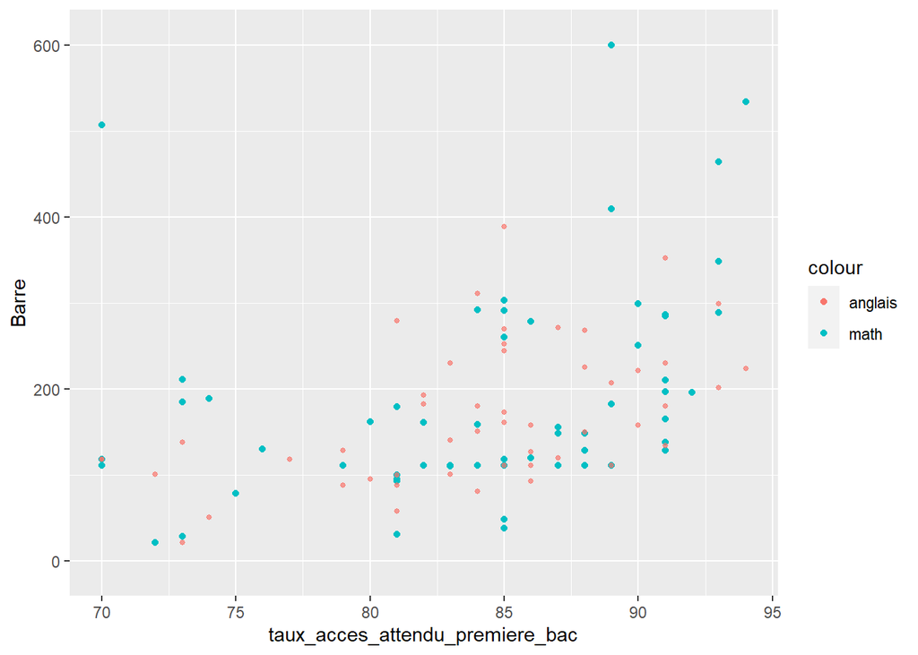

```r
library(ggplot2)
ggplot(d_math, aes(taux_acces_attendu_premiere_bac, Barre,color='math'))+geom_point()+geom_point(data = d_eng, aes(color = "anglais"),alpha=0.7,size=1)+ylim(-10, 610)
```

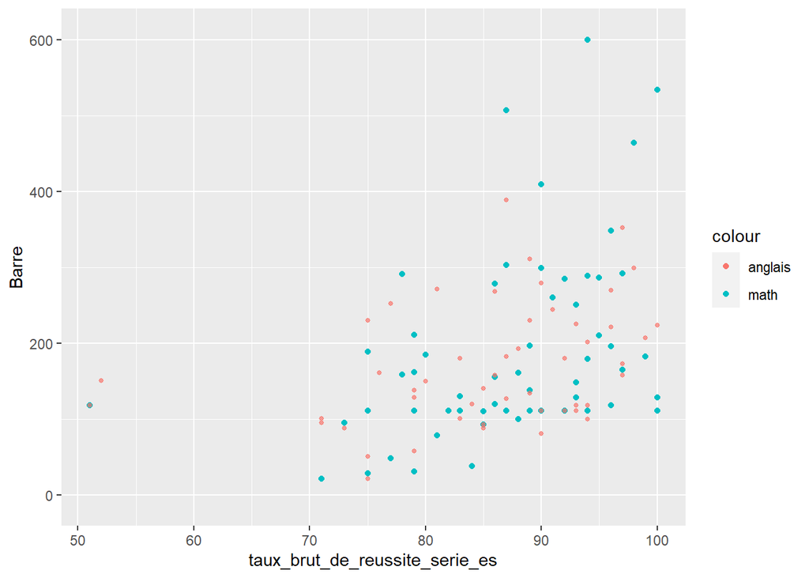

```r
ggplot(d_math, aes(taux_brut_de_reussite_serie_es, Barre,color='math'))+geom_point()+geom_point(data = d_eng, aes(color = "anglais"),alpha=0.7,size=1)+ylim(-10, 610)
```

### Analyse Fréquentist

#### Choix de modèle linéaire pour ‘points mutation en mathématique’ (fréquentist)

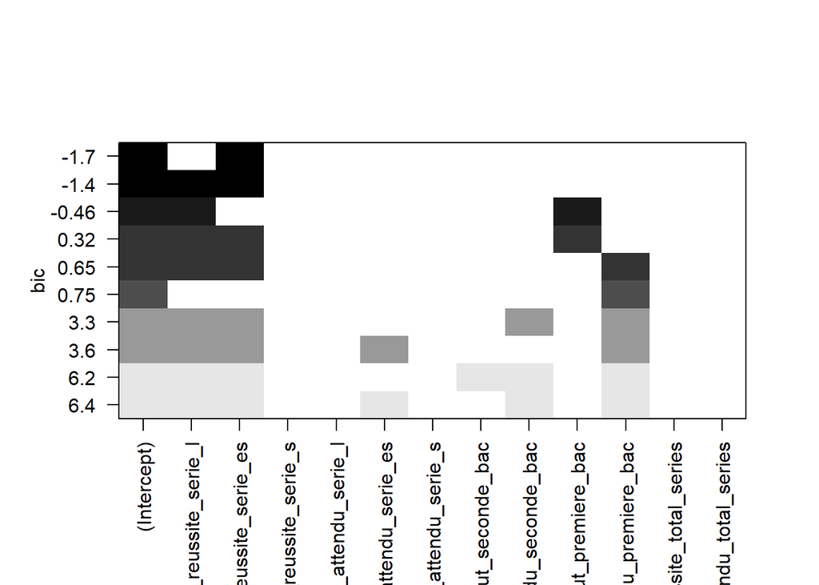

```r
lm_math_select=regsubsets(Barre~.,int=T,nbest=2,nvmax=5,method = "exhaustive",data = d_math[,c(6,10:15,18:23)])
plot(lm_math_select,scale="bic")
```

#### Choix de modèle linéaire pour ‘points mutation en anglais’ (fréquentist)

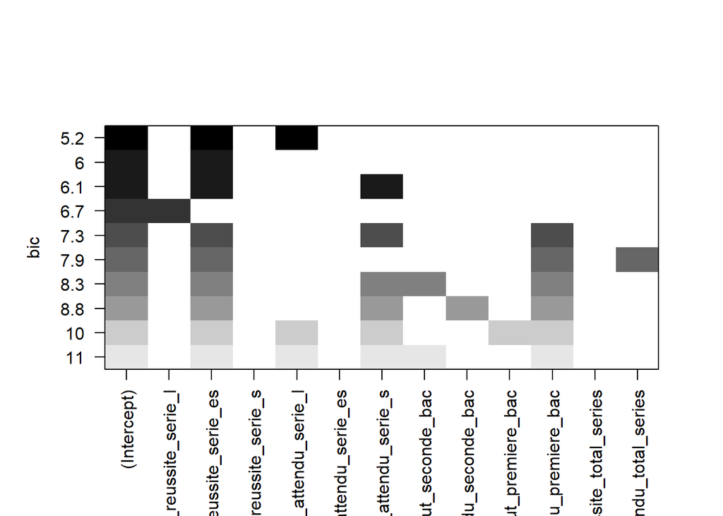

```r
lm_eng_select=regsubsets(Barre~.,int=T,nbest=2,nvmax=5,method = "exhaustive",data = d_eng[,c(6,10:15,18:23)])
plot(lm_eng_select,scale="bic")
```

Dans la sortie de regsubsets(), j’observe que les meilleurs 5 modèles choisissent des différentes covariables pour chacune de deux disciplines.

Neamoins, il exite un même modèle en commun parmis les meilleurs. Ce modèle contient une covariable seule ‘taux_brut_de_reussite_serie_es’. Par la suite, je vais ajuster la regression linéaire pour voir si cette variable agissment de la même manière sur les points de mutation en mathématique et en anglais.

#### regression linéaire ‘mathématique’(fréquentist)

```r
lm_math=lm(Barre~taux_brut_de_reussite_serie_es,d_math)
summary(lm_math)
```

```
##
## Call:
## lm(formula = Barre ~ taux_brut_de_reussite_serie_es, data = d_math)
##
## Residuals:
##     Min      1Q  Median      3Q     Max
## -145.97  -80.44  -34.60   60.41  375.63
##
## Coefficients:
##                                Estimate Std. Error t value Pr(>|t|)
## (Intercept)                    -286.357    148.068  -1.934  0.05809 .
## taux_brut_de_reussite_serie_es    5.433      1.688   3.220  0.00212 **
## ---
## Signif. codes:  0 '***' 0.001 '**' 0.01 '*' 0.05 '.' 0.1 ' ' 1
##
## Residual standard error: 115.6 on 57 degrees of freedom
## Multiple R-squared:  0.1539, Adjusted R-squared:  0.139
## F-statistic: 10.37 on 1 and 57 DF,  p-value: 0.00212
```

#### regression linéaire ‘anglais’(fréquentist)

```r
lm_eng=lm(Barre~taux_brut_de_reussite_serie_es,d_eng)
summary(lm_eng)
```

```
##
## Call:
## lm(formula = Barre ~ taux_brut_de_reussite_serie_es, data = d_eng)
##
## Residuals:
##     Min      1Q  Median      3Q     Max
## -171.43 -115.47  -61.92   -6.90 1446.57
##
## Coefficients:
##                                Estimate Std. Error t value Pr(>|t|)
## (Intercept)                    -234.823    342.934  -0.685    0.497
## taux_brut_de_reussite_serie_es    5.386      3.976   1.355    0.182
##
## Residual standard error: 292.8 on 50 degrees of freedom
## Multiple R-squared:  0.0354, Adjusted R-squared:  0.01611
## F-statistic: 1.835 on 1 and 50 DF,  p-value: 0.1816
```

En comparant la sortie de summary() pour deux disciplines, le coefficient estimé est similaire dans deux modèles. Néanmoins les P-value au niveau du coefficient et du test Fisher Global amènent aux différentes conclusions. Le modèle ‘mathématique’ considère ‘taux_brut_de_reussite_serie_es’ très siginificative( les deux p_value <0.005). En contraire, le modèle ‘anglais’ la considère non significative (les deux p_value >0.15 ), avec le nombre similaire d’observation que mathématique.

### Analyse Bayésienne

#### Choix de covariables significatives via l’approche bayésienne - mathématique

```r
lm_math_bms=bms(Barre~.,data=d_math[,c(6,10:15,18:23)],burn=5e3,iter=1e5)
```

```
##                                           PIP    Post Mean   Post SD
## taux_brut_de_reussite_serie_es     0.38207535  2.044054767 2.8743391
## taux_brut_de_reussite_serie_l      0.14624198 -0.479098952 1.3297188
## taux_acces_attendu_premiere_bac    0.13919468  1.065160712 3.3261769
## taux_acces_brut_premiere_bac       0.12123967  0.744164557 2.4019818
## taux_brut_de_reussite_total_series 0.07845264  0.348865749 1.6333536
## taux_reussite_attendu_total_series 0.06324093  0.180184469 1.6452459
## taux_reussite_attendu_serie_es     0.05915697  0.152690681 1.1484139
## taux_acces_brut_seconde_bac        0.05560931  0.152390633 0.9289582
## taux_acces_attendu_seconde_bac     0.05205512  0.086563262 1.0966871
## taux_reussite_attendu_serie_s      0.04584490 -0.046814712 1.0594536
## taux_brut_de_reussite_serie_s      0.03646504 -0.006393466 0.6206294
## taux_reussite_attendu_serie_l      0.03631125 -0.004120687 0.7834323
##                                    Cond.Pos.Sign Idx
## taux_brut_de_reussite_serie_es         1.0000000   2
## taux_brut_de_reussite_serie_l          0.0000000   1
## taux_acces_attendu_premiere_bac        1.0000000  10
## taux_acces_brut_premiere_bac           0.9941369   9
## taux_brut_de_reussite_total_series     0.9584815  11
## taux_reussite_attendu_total_series     0.8826785  12
## taux_reussite_attendu_serie_es         0.8636383   5
## taux_acces_brut_seconde_bac            0.9559302   7
## taux_acces_attendu_seconde_bac         0.7939544   8
## taux_reussite_attendu_serie_s          0.3897349   6
## taux_brut_de_reussite_serie_s          0.5171128   3
## taux_reussite_attendu_serie_l          0.3754599   4
##
## Mean no. regressors               Draws             Burnins                Time
##            "1.2159"              "4096"                 "0"    "0.3770421 secs"
##  No. models visited      Modelspace 2^K           % visited         % Topmodels
##              "4096"              "4096"               "100"                "12"
##            Corr PMP            No. Obs.         Model Prior             g-Prior
##                "NA"                "59"        "random / 6"               "UIP"
##     Shrinkage-Stats
##         "Av=0.9833"
##
## Time difference of 0.3770421 secs
```

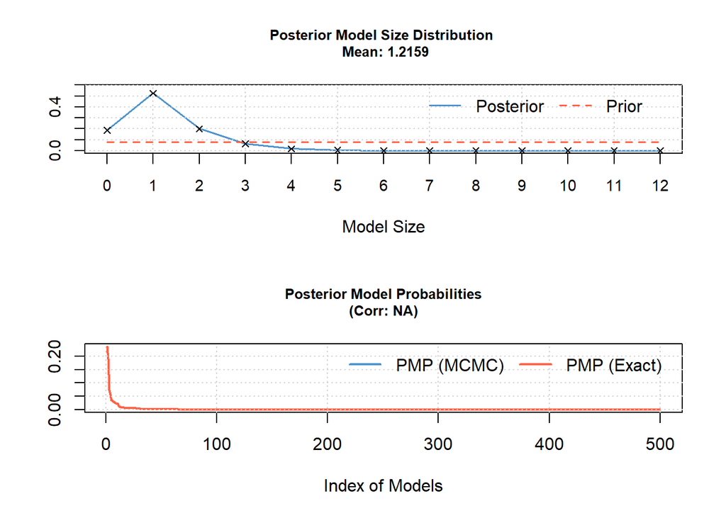

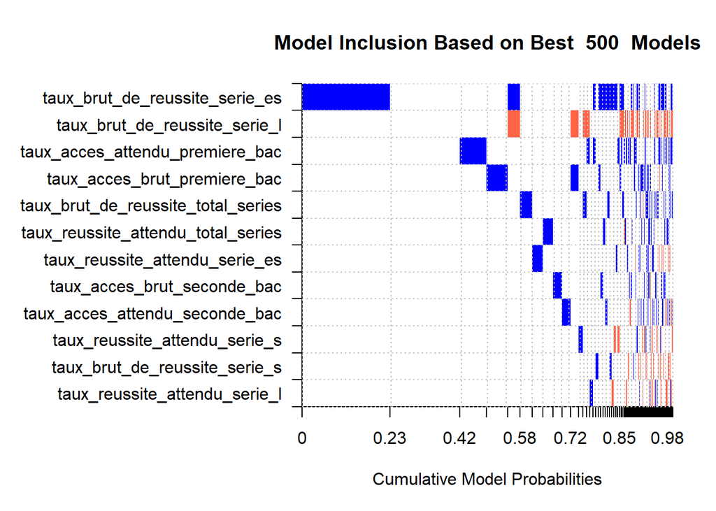

```r
image(lm_math_bms)
```

Selon la masse à posteriori, les modèles les plus probables contiennent 1 covaraibles.

Les covariables les plus probablement significatives sont:  
- 1ier: taux_brut_de_reussite_serie_es. 38% de la masse à posteriori a besoin de l’inclure.  
- 2ième: taux_brut_de_reussite_serie_l. 14% de la masse à posteriori a besoin de l’inclure.  
- 3ième: taux_acces_attendu_premiere_bac. 14% de la masse à posteriori a besoin de l’inclure.

#### Choix de covariables significatives via l’approche bayésienne - discipline anglais

```r
lm_eng_bms=bms(Barre~.,data=d_eng[,c(6,10:15,18:23)],burn=5e3,iter=1e5)
```

```
##                                           PIP   Post Mean   Post SD
## taux_brut_de_reussite_serie_es     0.06005036  0.48677290 2.2856363
## taux_reussite_attendu_serie_s      0.03087134 -0.30622913 2.5983049
## taux_reussite_attendu_serie_l      0.02999890 -0.25609584 2.0397365
## taux_brut_de_reussite_serie_l      0.02711375 -0.10334075 0.8630267
## taux_acces_attendu_premiere_bac    0.02345891  0.38811619 4.9139647
## taux_brut_de_reussite_serie_s      0.02318891 -0.10225766 1.1591175
## taux_reussite_attendu_total_series 0.02280731 -0.22240680 3.5072910
## taux_acces_brut_seconde_bac        0.02237336 -0.10128424 1.1215039
## taux_acces_attendu_seconde_bac     0.01936903 -0.08646451 1.5569186
## taux_acces_brut_premiere_bac       0.01933535 -0.09208431 1.5792710
## taux_reussite_attendu_serie_es     0.01894342  0.05307009 1.5272394
## taux_brut_de_reussite_total_series 0.01877338  0.04079586 1.7239170
##                                    Cond.Pos.Sign Idx
## taux_brut_de_reussite_serie_es        1.00000000   2
## taux_reussite_attendu_serie_s         0.00062849   6
## taux_reussite_attendu_serie_l         0.00128602   4
## taux_brut_de_reussite_serie_l         0.00023570   1
## taux_acces_attendu_premiere_bac       0.55548923  10
## taux_brut_de_reussite_serie_s         0.03297154   3
## taux_reussite_attendu_total_series    0.11585301  12
## taux_acces_brut_seconde_bac           0.00276401   7
## taux_acces_attendu_seconde_bac        0.11435026   8
## taux_acces_brut_premiere_bac          0.13033094   9
## taux_reussite_attendu_serie_es        0.41166150   5
## taux_brut_de_reussite_total_series    0.34832467  11
##
## Mean no. regressors               Draws             Burnins                Time
##            "0.3163"              "4096"                 "0"    "0.3920121 secs"
##  No. models visited      Modelspace 2^K           % visited         % Topmodels
##              "4096"              "4096"               "100"                "12"
##            Corr PMP            No. Obs.         Model Prior             g-Prior
##                "NA"                "52"        "random / 6"               "UIP"
##     Shrinkage-Stats
##         "Av=0.9811"
##
## Time difference of 0.3920121 secs
```

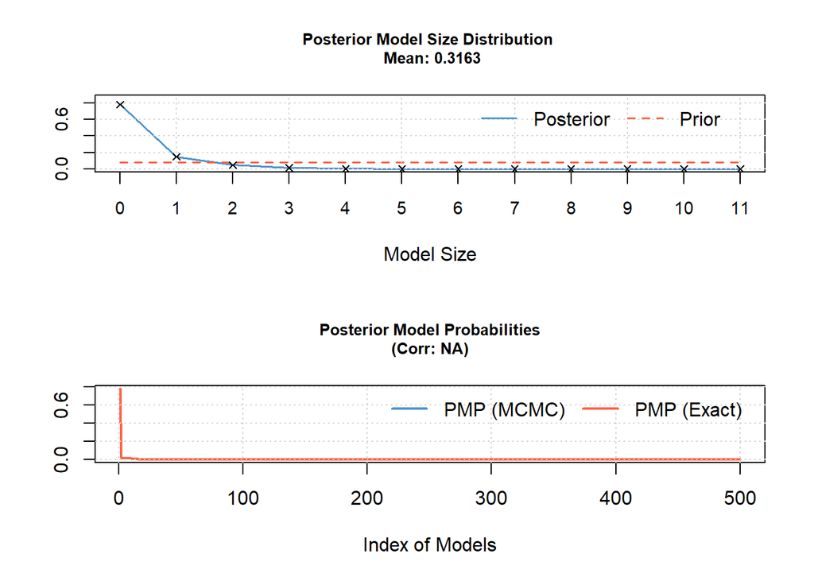

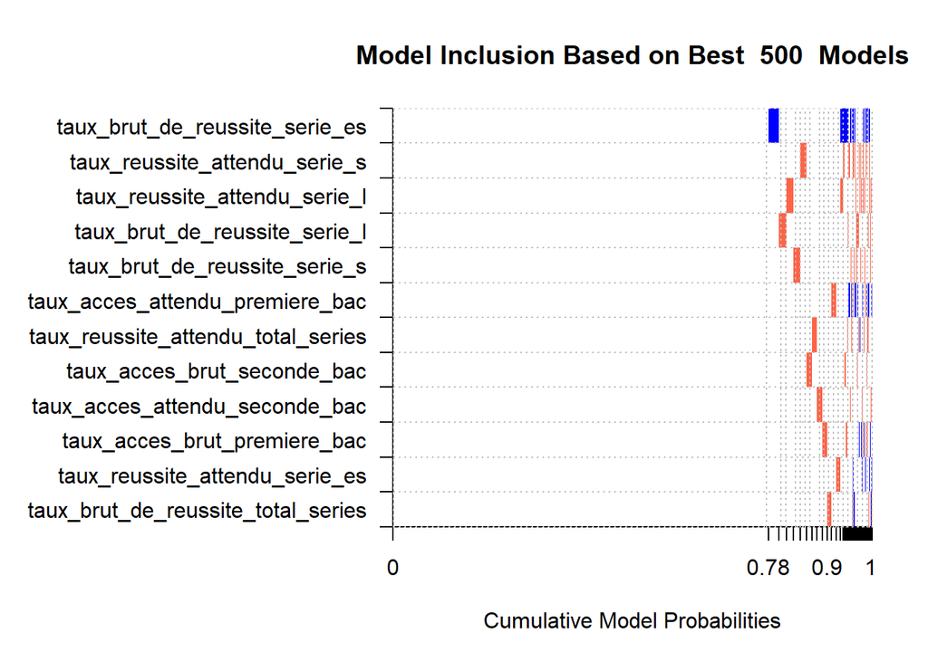

```r
image(lm_eng_bms)
```

Selon la masse à posteriori, les modèles les plus probables contiennent 0 covaraibles (versus 1 en mathématique).

Les covariables les plus probablement significatives sont:  
- 1ier: taux_brut_de_reussite_serie_es. 6% de la masse à posteriori a besoin de l’inclure (versus 38% en mathématique, 1ième).  
- 2ième: taux_reussite_attendu_serie_s. 3% de la masse à posteriori a besoin de l’inclure. (versus 4.5% en mathématique, 10ième)  
- 3ième: taux_reussite_attendu_serie_l. 3% de la masse à posteriori a besoin de l’inclure. (versus 3.6% en mathématique, 12ième)

Pour résumer, dans l’ensemble des analyses fréquentistes et bayésiennes, j’ai observé que les covariables n’agissent pas de la même manière dans les deux disciplines.

# 2 Loi de Pareto

## Question 4

J’utilise l’ensemble des fonctions sous le package ‘EnvStats’ pour simuler une loi Pareto.

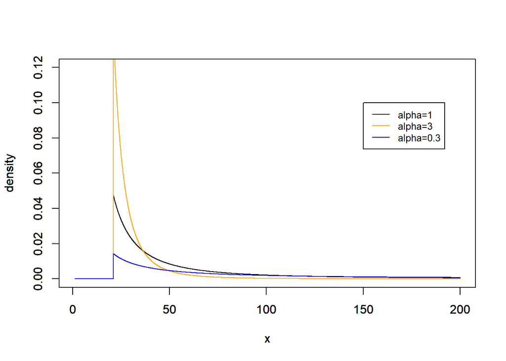

```r
library(EnvStats)
x=seq(1,200,by=0.01)
plot(x,dpareto(x,21,1),type='l',ylim=c(0,0.12),ylab = 'density')
par(new=TRUE)
plot(x,dpareto(x,21,3),type='l',ylim=c(0,0.12),ylab = 'density',col='orange')
par(new=TRUE)
plot(x,dpareto(x,21,0.3),type='l',ylim=c(0,0.12),ylab = 'density',col='blue')
legend(150,0.1, legend=c("alpha=1", "alpha=3","alpha=0.3"),col=c("black", "orange","blue"),lty=c(1,1,1), cex=0.8)
```

Comme montré par le graphe ci-dessus, plus $\alpha$ est grande, plus la distribution est concentrée dans les petites valeurs et que la queue de distribution est legère.

## Question 5

### Loi à priori

Après recherches sur Internet, il me parait pertinent de choisir une loi gamma, ou une loi gamma inversé étant à priori afin d’obtenir une famille de lois conjugée à ce modèle.

Je prend donc deux lois à priori suivantes pour la comparaison:  
- Gamma(1,1)  
- Gamma(2,2)

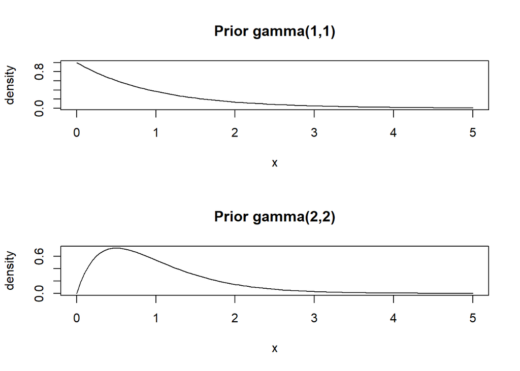

```r
par(mfrow=c(2,1))
#lois à priori gamma(1,1)
curve(dgamma(x,shape=1,rate=1),from=0, to=5, main="Prior gamma(1,1)", ylab="density")
#lois à priori gamma(2,2)
curve(dgamma(x,shape=2,rate=2),from=0, to=5, main="Prior gamma(2,2)", ylab="density")
```

## Question 6

### Loi à posteriori par conséquence

Après un calcul manuel(attaché sur Github), j’ai obtenu la loi à posteriori $\Gamma\left(n+a,\ \ b-n*ln(m)+\sum_{i=1}^{n} ln(y_{i})\right)$, qui correspond à la loi à priori $\Gamma(a,b)$.

Ci-dessous les graphes qui visualisent les deux lois à posteriori obtenues:

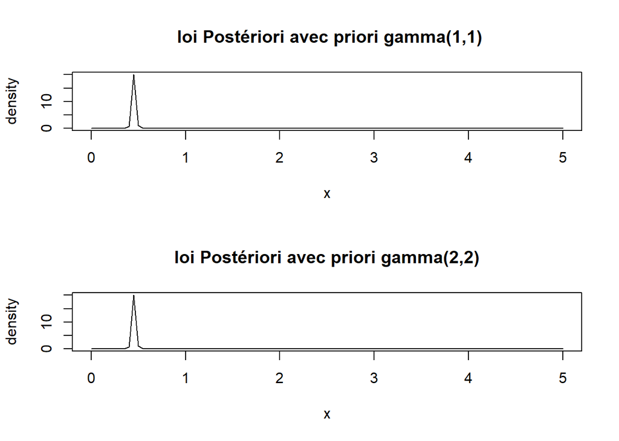

```r
n=nrow(d_muta)
library(SciViews)
m=21
sum_lnY=sum(ln(d_muta$Barre))
par(mfrow=c(2,1))
#loi à posteriori par conséquence de gamma(1,1)
curve(dgamma(x,shape=n+1,rate=1-n*ln(m)+sum_lnY),from=0, to=5, main=" loi Postériori avec priori gamma(1,1)", ylab="density")
#loi à posteriori par conséquence de gamma(2,2)
curve(dgamma(x,shape=n+2,rate=2-n*ln(m)+sum_lnY),from=0, to=5, main="loi Postériori avec priori gamma(2,2)", ylab="density")
```

A partir de deux lois à priori différentes, j’ai obtenu les deux lois à postériori quasiment pareilles, avec une variabilité faible.

## Question 7

```r
#médian et intervalle de crédibilité à 95%, relative à la loi à priori Gamma(1,1)
qgamma(p = c(0.025,0.5,0.975),shape=n+1,rate=1-n*ln(m)+sum_lnY)
```

```
## [1] 0.4126690 0.4503950 0.4903532
```

```r
#médian et intervalle de crédibilité à 95%, relative à la loi à priori Gamma(2,2)
qgamma(p = c(0.025,0.5,0.975),shape=n+2,rate=2-n*ln(m)+sum_lnY)
```

```
## [1] 0.4131430 0.4508737 0.4908346
```

A l’aide de fonction qgamma(), j’ai obtenu l’intervalle de credibilité à 95% [0.41,0.49] pour la paramètre $\alpha$ à partir de sa loi à posteriori.

## Question 8

En appliquant les mêmes analyses pour chacune de deux disciplines ‘mathématique’ et ‘anglais’, j’ai obtenu leur loi à postériori comme visualisé par les graphes ci-dessous:

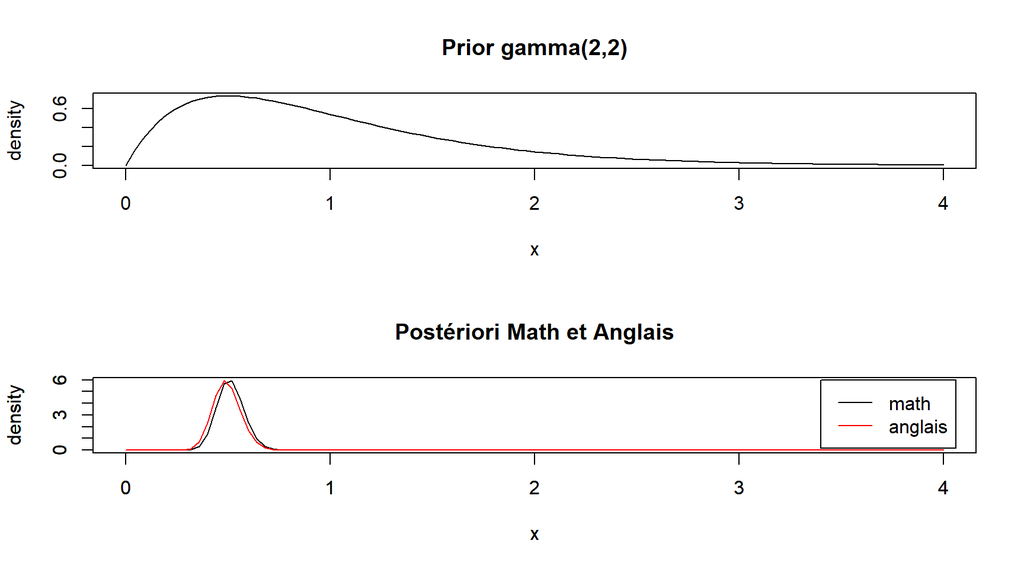

```r
n_math=nrow(d_math)
n_eng=nrow(d_eng)
sum_lnY_math=sum(ln(d_math$Barre))
sum_lnY_eng=sum(ln(d_eng$Barre))

par(mfrow=c(2,1))
#lois à priori gamma(2,2)
curve(dgamma(x,shape=2,rate=2),from=0, to=4, main="Prior gamma(2,2)", ylab="density")
#loi à posteriori par conséquence "math et anglais"
curve(dgamma(x,shape=n_math+2,rate=2-n_math*ln(m)+sum_lnY_math),from=0, to=4, main="Postériori Math et Anglais", ylab="density")
par(new=TRUE)
curve(dgamma(x,shape=n_eng+2,rate=2-n_eng*ln(m)+sum_lnY_eng),from=0, to=4, ylab="density",col='red')
legend(3.4,6,c('math','anglais'),col=c('black','red'),lty=c(1,1))
```

En observant les courbes pour le ‘modèle mathématique’ et pour celui d’anglais, je trouve que leur loi à postériori est quasiment pareille.

```r
qgamma(p = c(0.025,0.5,0.975),shape=n_math+2,rate=2-n_math*ln(m)+sum_lnY_math)
```

```
## [1] 0.3923232 0.5100940 0.6493733
```

```r
qgamma(p = c(0.025,0.5,0.975),shape=n_eng+2,rate=2-n_eng*ln(m)+sum_lnY_eng)
```

```
## [1] 0.3715631 0.4915560 0.6349758
```

L’intervalle de crédibilité à 95% de $\alpha$ pour le modèle mathématique est [0.39, 0.64]. Celle pour le modèle d’anglais est [0.37, 0.63]. Je trouve que ces valeurs sont très proches, ce qui soutient la hypothèse $\alpha_{math}=\alpha_{anglais}$.